# Risk Factor Analysis

## Outcome Variable

**Outcome Variable:** pers_wast

## Predictor Variables

**Intervention Variable:** nchldlt5

**Adjustment Set:**

- arm
- W_mage
- meducyrs
- feducyrs
- hhwealth_quart
- hfoodsec
- W_mhtcm
- W_mwtkg
- W_mbmi
- W_nrooms
- W_parity
- impfloor
- impsan
- safeh20
- delta_W_mage
- delta_meducyrs
- delta_feducyrs
- delta_hhwealth_quart
- delta_hfoodsec
- delta_W_mhtcm
- delta_W_mwtkg
- delta_W_mbmi
- delta_W_nrooms
- delta_W_parity
- delta_impfloor
- delta_impsan
- delta_safeh20

## Stratifying Variables

The analysis was stratified on these variable(s):

- agecat
- studyid
- country

## Data Summary

| agecat | studyid | country | nchldlt5 | pers_wast | n_cell | n |
| --- | --- | --- | --- | --- | --- | --- |
| 0-24 months | iLiNS-Zinc | BURKINA FASO | 1 | 0 | 488 | 1639 |
| 0-24 months | iLiNS-Zinc | BURKINA FASO | 1 | 1 | 62 | 1639 |
| 0-24 months | iLiNS-Zinc | BURKINA FASO | 2+ | 0 | 958 | 1639 |
| 0-24 months | iLiNS-Zinc | BURKINA FASO | 2+ | 1 | 131 | 1639 |
| 0-24 months | IRC | INDIA | 1 | 0 | 79 | 410 |
| 0-24 months | IRC | INDIA | 1 | 1 | 10 | 410 |
| 0-24 months | IRC | INDIA | 2+ | 0 | 283 | 410 |
| 0-24 months | IRC | INDIA | 2+ | 1 | 38 | 410 |
| 0-24 months | JiVitA-3 | BANGLADESH | 1 | 0 | 9569 | 15793 |
| 0-24 months | JiVitA-3 | BANGLADESH | 1 | 1 | 596 | 15793 |
| 0-24 months | JiVitA-3 | BANGLADESH | 2+ | 0 | 5327 | 15793 |
| 0-24 months | JiVitA-3 | BANGLADESH | 2+ | 1 | 301 | 15793 |
| 0-24 months | LCNI-5 | MALAWI | 1 | 0 | 337 | 711 |
| 0-24 months | LCNI-5 | MALAWI | 1 | 1 | 4 | 711 |
| 0-24 months | LCNI-5 | MALAWI | 2+ | 0 | 368 | 711 |
| 0-24 months | LCNI-5 | MALAWI | 2+ | 1 | 2 | 711 |
| 0-24 months | NIH-Crypto | BANGLADESH | 1 | 0 | 504 | 730 |
| 0-24 months | NIH-Crypto | BANGLADESH | 1 | 1 | 16 | 730 |
| 0-24 months | NIH-Crypto | BANGLADESH | 2+ | 0 | 200 | 730 |
| 0-24 months | NIH-Crypto | BANGLADESH | 2+ | 1 | 10 | 730 |
| 0-24 months | PROVIDE | BANGLADESH | 1 | 0 | 460 | 641 |
| 0-24 months | PROVIDE | BANGLADESH | 1 | 1 | 10 | 641 |
| 0-24 months | PROVIDE | BANGLADESH | 2+ | 0 | 166 | 641 |
| 0-24 months | PROVIDE | BANGLADESH | 2+ | 1 | 5 | 641 |
| 0-24 months | TanzaniaChild2 | TANZANIA, UNITED REPUBLIC OF | 1 | 0 | 1440 | 2157 |
| 0-24 months | TanzaniaChild2 | TANZANIA, UNITED REPUBLIC OF | 1 | 1 | 38 | 2157 |
| 0-24 months | TanzaniaChild2 | TANZANIA, UNITED REPUBLIC OF | 2+ | 0 | 659 | 2157 |
| 0-24 months | TanzaniaChild2 | TANZANIA, UNITED REPUBLIC OF | 2+ | 1 | 20 | 2157 |
| 0-6 months | IRC | INDIA | 1 | 0 | 69 | 402 |
| 0-6 months | IRC | INDIA | 1 | 1 | 16 | 402 |
| 0-6 months | IRC | INDIA | 2+ | 0 | 269 | 402 |
| 0-6 months | IRC | INDIA | 2+ | 1 | 48 | 402 |
| 0-6 months | JiVitA-3 | BANGLADESH | 1 | 0 | 31 | 50 |
| 0-6 months | JiVitA-3 | BANGLADESH | 1 | 1 | 1 | 50 |
| 0-6 months | JiVitA-3 | BANGLADESH | 2+ | 0 | 17 | 50 |
| 0-6 months | JiVitA-3 | BANGLADESH | 2+ | 1 | 1 | 50 |
| 0-6 months | NIH-Crypto | BANGLADESH | 1 | 0 | 193 | 250 |
| 0-6 months | NIH-Crypto | BANGLADESH | 1 | 1 | 4 | 250 |
| 0-6 months | NIH-Crypto | BANGLADESH | 2+ | 0 | 52 | 250 |
| 0-6 months | NIH-Crypto | BANGLADESH | 2+ | 1 | 1 | 250 |
| 0-6 months | PROVIDE | BANGLADESH | 1 | 0 | 459 | 638 |
| 0-6 months | PROVIDE | BANGLADESH | 1 | 1 | 9 | 638 |
| 0-6 months | PROVIDE | BANGLADESH | 2+ | 0 | 165 | 638 |
| 0-6 months | PROVIDE | BANGLADESH | 2+ | 1 | 5 | 638 |
| 0-6 months | TanzaniaChild2 | TANZANIA, UNITED REPUBLIC OF | 1 | 0 | 1372 | 2053 |
| 0-6 months | TanzaniaChild2 | TANZANIA, UNITED REPUBLIC OF | 1 | 1 | 36 | 2053 |
| 0-6 months | TanzaniaChild2 | TANZANIA, UNITED REPUBLIC OF | 2+ | 0 | 629 | 2053 |
| 0-6 months | TanzaniaChild2 | TANZANIA, UNITED REPUBLIC OF | 2+ | 1 | 16 | 2053 |
| 6-24 months | iLiNS-Zinc | BURKINA FASO | 1 | 0 | 488 | 1639 |
| 6-24 months | iLiNS-Zinc | BURKINA FASO | 1 | 1 | 62 | 1639 |
| 6-24 months | iLiNS-Zinc | BURKINA FASO | 2+ | 0 | 958 | 1639 |
| 6-24 months | iLiNS-Zinc | BURKINA FASO | 2+ | 1 | 131 | 1639 |
| 6-24 months | IRC | INDIA | 1 | 0 | 79 | 410 |
| 6-24 months | IRC | INDIA | 1 | 1 | 10 | 410 |
| 6-24 months | IRC | INDIA | 2+ | 0 | 283 | 410 |
| 6-24 months | IRC | INDIA | 2+ | 1 | 38 | 410 |
| 6-24 months | JiVitA-3 | BANGLADESH | 1 | 0 | 9569 | 15793 |
| 6-24 months | JiVitA-3 | BANGLADESH | 1 | 1 | 596 | 15793 |
| 6-24 months | JiVitA-3 | BANGLADESH | 2+ | 0 | 5327 | 15793 |
| 6-24 months | JiVitA-3 | BANGLADESH | 2+ | 1 | 301 | 15793 |
| 6-24 months | LCNI-5 | MALAWI | 1 | 0 | 337 | 711 |
| 6-24 months | LCNI-5 | MALAWI | 1 | 1 | 4 | 711 |
| 6-24 months | LCNI-5 | MALAWI | 2+ | 0 | 368 | 711 |
| 6-24 months | LCNI-5 | MALAWI | 2+ | 1 | 2 | 711 |
| 6-24 months | NIH-Crypto | BANGLADESH | 1 | 0 | 504 | 730 |
| 6-24 months | NIH-Crypto | BANGLADESH | 1 | 1 | 16 | 730 |
| 6-24 months | NIH-Crypto | BANGLADESH | 2+ | 0 | 200 | 730 |
| 6-24 months | NIH-Crypto | BANGLADESH | 2+ | 1 | 10 | 730 |
| 6-24 months | PROVIDE | BANGLADESH | 1 | 0 | 460 | 641 |
| 6-24 months | PROVIDE | BANGLADESH | 1 | 1 | 10 | 641 |
| 6-24 months | PROVIDE | BANGLADESH | 2+ | 0 | 166 | 641 |
| 6-24 months | PROVIDE | BANGLADESH | 2+ | 1 | 5 | 641 |
| 6-24 months | TanzaniaChild2 | TANZANIA, UNITED REPUBLIC OF | 1 | 0 | 1440 | 2157 |
| 6-24 months | TanzaniaChild2 | TANZANIA, UNITED REPUBLIC OF | 1 | 1 | 38 | 2157 |
| 6-24 months | TanzaniaChild2 | TANZANIA, UNITED REPUBLIC OF | 2+ | 0 | 659 | 2157 |
| 6-24 months | TanzaniaChild2 | TANZANIA, UNITED REPUBLIC OF | 2+ | 1 | 20 | 2157 |

The following strata were considered:

- agecat: 0-24 months, studyid: iLiNS-Zinc, country: BURKINA FASO
- agecat: 0-24 months, studyid: IRC, country: INDIA
- agecat: 0-24 months, studyid: JiVitA-3, country: BANGLADESH
- agecat: 0-24 months, studyid: LCNI-5, country: MALAWI
- agecat: 0-24 months, studyid: NIH-Crypto, country: BANGLADESH
- agecat: 0-24 months, studyid: PROVIDE, country: BANGLADESH
- agecat: 0-24 months, studyid: TanzaniaChild2, country: TANZANIA, UNITED REPUBLIC OF
- agecat: 0-6 months, studyid: IRC, country: INDIA
- agecat: 0-6 months, studyid: JiVitA-3, country: BANGLADESH
- agecat: 0-6 months, studyid: NIH-Crypto, country: BANGLADESH
- agecat: 0-6 months, studyid: PROVIDE, country: BANGLADESH
- agecat: 0-6 months, studyid: TanzaniaChild2, country: TANZANIA, UNITED REPUBLIC OF
- agecat: 6-24 months, studyid: iLiNS-Zinc, country: BURKINA FASO
- agecat: 6-24 months, studyid: IRC, country: INDIA
- agecat: 6-24 months, studyid: JiVitA-3, country: BANGLADESH
- agecat: 6-24 months, studyid: LCNI-5, country: MALAWI
- agecat: 6-24 months, studyid: NIH-Crypto, country: BANGLADESH
- agecat: 6-24 months, studyid: PROVIDE, country: BANGLADESH
- agecat: 6-24 months, studyid: TanzaniaChild2, country: TANZANIA, UNITED REPUBLIC OF

### Dropped Strata

Some strata were dropped due to rare outcomes:

- agecat: 0-24 months, studyid: LCNI-5, country: MALAWI
- agecat: 0-6 months, studyid: JiVitA-3, country: BANGLADESH
- agecat: 0-6 months, studyid: NIH-Crypto, country: BANGLADESH
- agecat: 6-24 months, studyid: LCNI-5, country: MALAWI

## Methods Detail

We’re interested in the causal parameters $E[Y_a]$ for all values of $a \in \mathcal{A}$. These parameters represent the mean outcome if, possibly contrary to fact, we intervened to set all units to have $A=a$. Under the randomization and positivity assumptions, these are identified by the statistical parameters $\psi_a=E_W[E_{Y|A,W}(Y|A=a,W)]$. In addition, we’re interested in the mean of $Y$, $E[Y]$ under no intervention (the observed mean). We will estimate these parameters by using SuperLearner to fit the relevant likelihood factors – $E_{Y|A,W}(Y|A=a,W)$ and $p(A=a|W)$, and then updating our likelihood fit using a joint TMLE.

For unadjusted analyses ($W=\{\}$), initial likelihoods were estimated using Lrnr_glm to estimate the simple $E(Y|A)$ and Lrnr_mean to estimate $p(A)$. For adjusted analyses, a small library containing Lrnr_glmnet, Lrnr_xgboost, and Lrnr_mean was used.

Having estimated these parameters, we will then use the delta method to estimate relative risks and attributable risks relative to a prespecified baseline level of $A$.

# Results Detail

## Results Plots

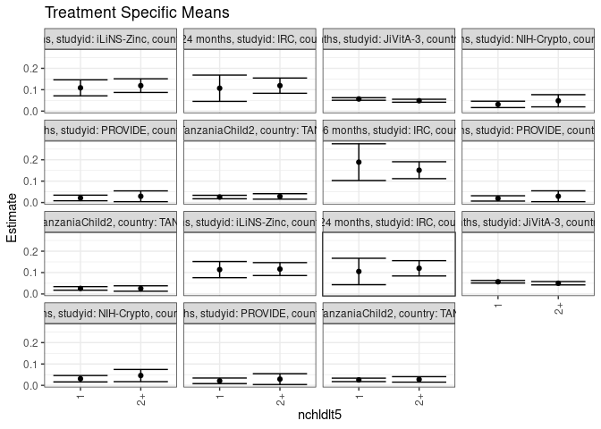

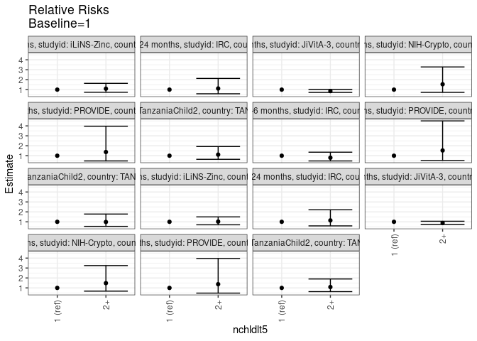

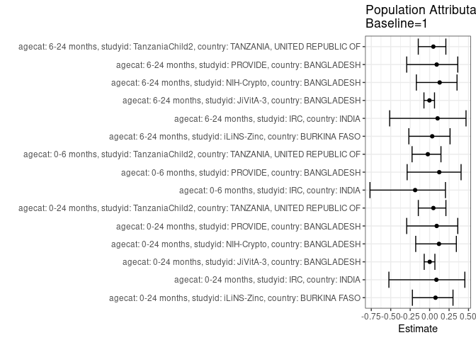

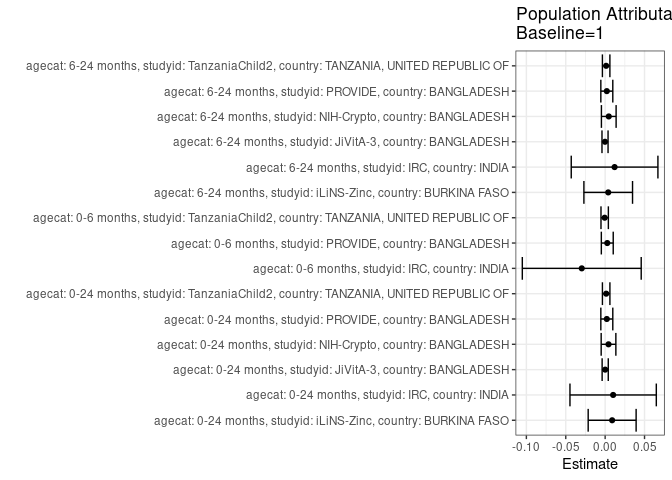

## Results Table

### Parameter: TSM

| agecat | studyid | country | intervention_level | baseline_level | estimate | ci_lower | ci_upper |
| --- | --- | --- | --- | --- | --- | --- | --- |
| 0-24 months | iLiNS-Zinc | BURKINA FASO | 1 | NA | 0.1088588 | 0.0713308 | 0.1463869 |
| 0-24 months | iLiNS-Zinc | BURKINA FASO | 2+ | NA | 0.1191204 | 0.0872196 | 0.1510213 |
| 0-24 months | IRC | INDIA | 1 | NA | 0.1069282 | 0.0454566 | 0.1683998 |
| 0-24 months | IRC | INDIA | 2+ | NA | 0.1190942 | 0.0834250 | 0.1547635 |
| 0-24 months | JiVitA-3 | BANGLADESH | 1 | NA | 0.0567276 | 0.0508233 | 0.0626318 |
| 0-24 months | JiVitA-3 | BANGLADESH | 2+ | NA | 0.0485060 | 0.0415101 | 0.0555018 |
| 0-24 months | NIH-Crypto | BANGLADESH | 1 | NA | 0.0313346 | 0.0164094 | 0.0462598 |
| 0-24 months | NIH-Crypto | BANGLADESH | 2+ | NA | 0.0482513 | 0.0197209 | 0.0767818 |
| 0-24 months | PROVIDE | BANGLADESH | 1 | NA | 0.0212766 | 0.0082203 | 0.0343329 |
| 0-24 months | PROVIDE | BANGLADESH | 2+ | NA | 0.0292398 | 0.0039682 | 0.0545113 |
| 0-24 months | TanzaniaChild2 | TANZANIA, UNITED REPUBLIC OF | 1 | NA | 0.0255900 | 0.0175111 | 0.0336688 |
| 0-24 months | TanzaniaChild2 | TANZANIA, UNITED REPUBLIC OF | 2+ | NA | 0.0284130 | 0.0156345 | 0.0411916 |
| 0-6 months | IRC | INDIA | 1 | NA | 0.1888893 | 0.1028240 | 0.2749546 |
| 0-6 months | IRC | INDIA | 2+ | NA | 0.1511310 | 0.1115528 | 0.1907091 |
| 0-6 months | PROVIDE | BANGLADESH | 1 | NA | 0.0192308 | 0.0067785 | 0.0316830 |
| 0-6 months | PROVIDE | BANGLADESH | 2+ | NA | 0.0294118 | 0.0039937 | 0.0548298 |
| 0-6 months | TanzaniaChild2 | TANZANIA, UNITED REPUBLIC OF | 1 | NA | 0.0259205 | 0.0175526 | 0.0342884 |
| 0-6 months | TanzaniaChild2 | TANZANIA, UNITED REPUBLIC OF | 2+ | NA | 0.0254614 | 0.0127252 | 0.0381977 |
| 6-24 months | iLiNS-Zinc | BURKINA FASO | 1 | NA | 0.1138485 | 0.0759958 | 0.1517013 |
| 6-24 months | iLiNS-Zinc | BURKINA FASO | 2+ | NA | 0.1163188 | 0.0860883 | 0.1465493 |
| 6-24 months | IRC | INDIA | 1 | NA | 0.1050949 | 0.0432990 | 0.1668908 |
| 6-24 months | IRC | INDIA | 2+ | NA | 0.1199764 | 0.0841569 | 0.1557959 |
| 6-24 months | JiVitA-3 | BANGLADESH | 1 | NA | 0.0569550 | 0.0510443 | 0.0628657 |
| 6-24 months | JiVitA-3 | BANGLADESH | 2+ | NA | 0.0500635 | 0.0422842 | 0.0578427 |
| 6-24 months | NIH-Crypto | BANGLADESH | 1 | NA | 0.0310181 | 0.0160890 | 0.0459471 |
| 6-24 months | NIH-Crypto | BANGLADESH | 2+ | NA | 0.0459538 | 0.0173719 | 0.0745356 |
| 6-24 months | PROVIDE | BANGLADESH | 1 | NA | 0.0212766 | 0.0082203 | 0.0343329 |
| 6-24 months | PROVIDE | BANGLADESH | 2+ | NA | 0.0292398 | 0.0039682 | 0.0545113 |
| 6-24 months | TanzaniaChild2 | TANZANIA, UNITED REPUBLIC OF | 1 | NA | 0.0256088 | 0.0175250 | 0.0336925 |
| 6-24 months | TanzaniaChild2 | TANZANIA, UNITED REPUBLIC OF | 2+ | NA | 0.0279020 | 0.0151379 | 0.0406660 |

### Parameter: E(Y)

| agecat | studyid | country | intervention_level | baseline_level | estimate | ci_lower | ci_upper |
| --- | --- | --- | --- | --- | --- | --- | --- |
| 0-24 months | iLiNS-Zinc | BURKINA FASO | NA | NA | 0.1177547 | 0.0931926 | 0.1423168 |
| 0-24 months | IRC | INDIA | NA | NA | 0.1170732 | 0.0859146 | 0.1482317 |
| 0-24 months | JiVitA-3 | BANGLADESH | NA | NA | 0.0567973 | 0.0526805 | 0.0609141 |
| 0-24 months | NIH-Crypto | BANGLADESH | NA | NA | 0.0356164 | 0.0221630 | 0.0490699 |
| 0-24 months | PROVIDE | BANGLADESH | NA | NA | 0.0234009 | 0.0116889 | 0.0351130 |
| 0-24 months | TanzaniaChild2 | TANZANIA, UNITED REPUBLIC OF | NA | NA | 0.0268892 | 0.0200612 | 0.0337172 |
| 0-6 months | IRC | INDIA | NA | NA | 0.1592040 | 0.1233945 | 0.1950135 |
| 0-6 months | PROVIDE | BANGLADESH | NA | NA | 0.0219436 | 0.0105669 | 0.0333202 |
| 0-6 months | TanzaniaChild2 | TANZANIA, UNITED REPUBLIC OF | NA | NA | 0.0253288 | 0.0185306 | 0.0321270 |
| 6-24 months | iLiNS-Zinc | BURKINA FASO | NA | NA | 0.1177547 | 0.0931926 | 0.1423168 |
| 6-24 months | IRC | INDIA | NA | NA | 0.1170732 | 0.0859146 | 0.1482317 |
| 6-24 months | JiVitA-3 | BANGLADESH | NA | NA | 0.0567973 | 0.0526805 | 0.0609141 |
| 6-24 months | NIH-Crypto | BANGLADESH | NA | NA | 0.0356164 | 0.0221630 | 0.0490699 |
| 6-24 months | PROVIDE | BANGLADESH | NA | NA | 0.0234009 | 0.0116889 | 0.0351130 |
| 6-24 months | TanzaniaChild2 | TANZANIA, UNITED REPUBLIC OF | NA | NA | 0.0268892 | 0.0200612 | 0.0337172 |

### Parameter: RR

| agecat | studyid | country | intervention_level | baseline_level | estimate | ci_lower | ci_upper |
| --- | --- | --- | --- | --- | --- | --- | --- |
| 0-24 months | iLiNS-Zinc | BURKINA FASO | 1 | 1 | 1.0000000 | 1.0000000 | 1.000000 |
| 0-24 months | iLiNS-Zinc | BURKINA FASO | 2+ | 1 | 1.0942653 | 0.7335534 | 1.632351 |
| 0-24 months | IRC | INDIA | 1 | 1 | 1.0000000 | 1.0000000 | 1.000000 |
| 0-24 months | IRC | INDIA | 2+ | 1 | 1.1137778 | 0.5825132 | 2.129567 |
| 0-24 months | JiVitA-3 | BANGLADESH | 1 | 1 | 1.0000000 | 1.0000000 | 1.000000 |
| 0-24 months | JiVitA-3 | BANGLADESH | 2+ | 1 | 0.8550692 | 0.7169470 | 1.019801 |
| 0-24 months | NIH-Crypto | BANGLADESH | 1 | 1 | 1.0000000 | 1.0000000 | 1.000000 |
| 0-24 months | NIH-Crypto | BANGLADESH | 2+ | 1 | 1.5398729 | 0.7225430 | 3.281754 |
| 0-24 months | PROVIDE | BANGLADESH | 1 | 1 | 1.0000000 | 1.0000000 | 1.000000 |
| 0-24 months | PROVIDE | BANGLADESH | 2+ | 1 | 1.3742690 | 0.4761342 | 3.966561 |
| 0-24 months | TanzaniaChild2 | TANZANIA, UNITED REPUBLIC OF | 1 | 1 | 1.0000000 | 1.0000000 | 1.000000 |
| 0-24 months | TanzaniaChild2 | TANZANIA, UNITED REPUBLIC OF | 2+ | 1 | 1.1103202 | 0.6409675 | 1.923360 |
| 0-6 months | IRC | INDIA | 1 | 1 | 1.0000000 | 1.0000000 | 1.000000 |
| 0-6 months | IRC | INDIA | 2+ | 1 | 0.8001033 | 0.4728150 | 1.353945 |
| 0-6 months | PROVIDE | BANGLADESH | 1 | 1 | 1.0000000 | 1.0000000 | 1.000000 |
| 0-6 months | PROVIDE | BANGLADESH | 2+ | 1 | 1.5294118 | 0.5194431 | 4.503092 |
| 0-6 months | TanzaniaChild2 | TANZANIA, UNITED REPUBLIC OF | 1 | 1 | 1.0000000 | 1.0000000 | 1.000000 |
| 0-6 months | TanzaniaChild2 | TANZANIA, UNITED REPUBLIC OF | 2+ | 1 | 0.9822886 | 0.5417489 | 1.781067 |
| 6-24 months | iLiNS-Zinc | BURKINA FASO | 1 | 1 | 1.0000000 | 1.0000000 | 1.000000 |
| 6-24 months | iLiNS-Zinc | BURKINA FASO | 2+ | 1 | 1.0216979 | 0.6985289 | 1.494379 |
| 6-24 months | IRC | INDIA | 1 | 1 | 1.0000000 | 1.0000000 | 1.000000 |
| 6-24 months | IRC | INDIA | 2+ | 1 | 1.1416004 | 0.5901901 | 2.208189 |
| 6-24 months | JiVitA-3 | BANGLADESH | 1 | 1 | 1.0000000 | 1.0000000 | 1.000000 |
| 6-24 months | JiVitA-3 | BANGLADESH | 2+ | 1 | 0.8790004 | 0.7311757 | 1.056712 |
| 6-24 months | NIH-Crypto | BANGLADESH | 1 | 1 | 1.0000000 | 1.0000000 | 1.000000 |
| 6-24 months | NIH-Crypto | BANGLADESH | 2+ | 1 | 1.4815160 | 0.6764331 | 3.244799 |
| 6-24 months | PROVIDE | BANGLADESH | 1 | 1 | 1.0000000 | 1.0000000 | 1.000000 |
| 6-24 months | PROVIDE | BANGLADESH | 2+ | 1 | 1.3742690 | 0.4761342 | 3.966561 |
| 6-24 months | TanzaniaChild2 | TANZANIA, UNITED REPUBLIC OF | 1 | 1 | 1.0000000 | 1.0000000 | 1.000000 |
| 6-24 months | TanzaniaChild2 | TANZANIA, UNITED REPUBLIC OF | 2+ | 1 | 1.0895471 | 0.6251322 | 1.898979 |

### Parameter: PAR

| agecat | studyid | country | intervention_level | baseline_level | estimate | ci_lower | ci_upper |
| --- | --- | --- | --- | --- | --- | --- | --- |
| 0-24 months | iLiNS-Zinc | BURKINA FASO | 1 | NA | 0.0088959 | -0.0215361 | 0.0393278 |
| 0-24 months | IRC | INDIA | 1 | NA | 0.0101450 | -0.0446666 | 0.0649566 |
| 0-24 months | JiVitA-3 | BANGLADESH | 1 | NA | 0.0000698 | -0.0038255 | 0.0039650 |
| 0-24 months | NIH-Crypto | BANGLADESH | 1 | NA | 0.0042818 | -0.0050412 | 0.0136049 |
| 0-24 months | PROVIDE | BANGLADESH | 1 | NA | 0.0021243 | -0.0054689 | 0.0097175 |
| 0-24 months | TanzaniaChild2 | TANZANIA, UNITED REPUBLIC OF | 1 | NA | 0.0012992 | -0.0034511 | 0.0060495 |
| 0-6 months | IRC | INDIA | 1 | NA | -0.0296853 | -0.1051535 | 0.0457828 |
| 0-6 months | PROVIDE | BANGLADESH | 1 | NA | 0.0027128 | -0.0048372 | 0.0102628 |
| 0-6 months | TanzaniaChild2 | TANZANIA, UNITED REPUBLIC OF | 1 | NA | -0.0005917 | -0.0052740 | 0.0040905 |
| 6-24 months | iLiNS-Zinc | BURKINA FASO | 1 | NA | 0.0039062 | -0.0269683 | 0.0347807 |
| 6-24 months | IRC | INDIA | 1 | NA | 0.0119783 | -0.0430381 | 0.0669946 |
| 6-24 months | JiVitA-3 | BANGLADESH | 1 | NA | -0.0001577 | -0.0040129 | 0.0036975 |
| 6-24 months | NIH-Crypto | BANGLADESH | 1 | NA | 0.0045984 | -0.0047279 | 0.0139246 |
| 6-24 months | PROVIDE | BANGLADESH | 1 | NA | 0.0021243 | -0.0054689 | 0.0097175 |
| 6-24 months | TanzaniaChild2 | TANZANIA, UNITED REPUBLIC OF | 1 | NA | 0.0012804 | -0.0034687 | 0.0060296 |

### Parameter: PAF

| agecat | studyid | country | intervention_level | baseline_level | estimate | ci_lower | ci_upper |
| --- | --- | --- | --- | --- | --- | --- | --- |
| 0-24 months | iLiNS-Zinc | BURKINA FASO | 1 | NA | 0.0755460 | -0.2215743 | 0.3003985 |
| 0-24 months | IRC | INDIA | 1 | NA | 0.0866551 | -0.5236815 | 0.4525109 |
| 0-24 months | JiVitA-3 | BANGLADESH | 1 | NA | 0.0012283 | -0.0697714 | 0.0675159 |
| 0-24 months | NIH-Crypto | BANGLADESH | 1 | NA | 0.1202206 | -0.1789157 | 0.3434545 |
| 0-24 months | PROVIDE | BANGLADESH | 1 | NA | 0.0907801 | -0.2947917 | 0.3615338 |
| 0-24 months | TanzaniaChild2 | TANZANIA, UNITED REPUBLIC OF | 1 | NA | 0.0483183 | -0.1454239 | 0.2092900 |
| 0-6 months | IRC | INDIA | 1 | NA | -0.1864609 | -0.7669667 | 0.2033299 |
| 0-6 months | PROVIDE | BANGLADESH | 1 | NA | 0.1236264 | -0.2892206 | 0.4042674 |
| 0-6 months | TanzaniaChild2 | TANZANIA, UNITED REPUBLIC OF | 1 | NA | -0.0233626 | -0.2258741 | 0.1456944 |
| 6-24 months | iLiNS-Zinc | BURKINA FASO | 1 | NA | 0.0331724 | -0.2673964 | 0.2624599 |
| 6-24 months | IRC | INDIA | 1 | NA | 0.1023144 | -0.5141471 | 0.4677931 |
| 6-24 months | JiVitA-3 | BANGLADESH | 1 | NA | -0.0027763 | -0.0729813 | 0.0628352 |
| 6-24 months | NIH-Crypto | BANGLADESH | 1 | NA | 0.1291077 | -0.1706332 | 0.3520999 |
| 6-24 months | PROVIDE | BANGLADESH | 1 | NA | 0.0907801 | -0.2947917 | 0.3615338 |
| 6-24 months | TanzaniaChild2 | TANZANIA, UNITED REPUBLIC OF | 1 | NA | 0.0476188 | -0.1460772 | 0.2085786 |